# Group Project: Spotify

# (3) We decide to draw a heatmap to visualize the correlation between the numeric variables in the dataset.

1. Heatmaps use colors and numbers to indicate the linear correlation between variables, with values ranging from -1 to 1.
2. The colors range from red (negative correlation) to blue (positive correlation), and the darker the color, the stronger the correlation.
3. The area above the diagonal is blank (only the lower triangle is displayed), which improves simplicity.
4. The heatmap will help us identify any strong correlations between features, which can be useful for feature selection in predictive modeling.

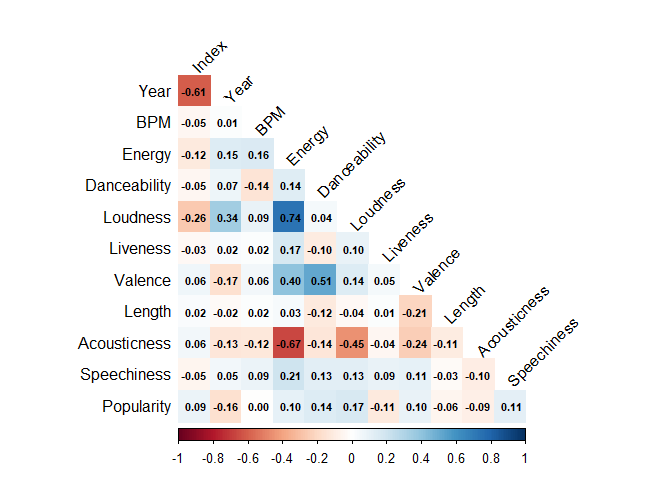

# Key observations: (a) Energy and Loudness have the highest correlation (0.74): music with high energy tends to be louder. (b) Acousticness and Energy have the strongest negative correlation (-0.67): music with high acoustics tends to have low energy (softer). (c) Popularity has weak correlations with other variables (the absolute value is basically < 0.2), indicating that popularity is affected by more complex factors and is not determined by these audio features alone.

# (4) Linear Model: deviding the dataset into train, valid and test

(a)Firstly we got rid of all NA values by using the `na.omit` function. (b)Then used the `createDataPartition` function to create an index for the distribution of the variable, `Popularity`. (c)The division of the original is 50%, 30%, and 20% for the train, valid and test data frame respectively. (d)To split the division we made four new objects: - `df_train`, which corresponds to 50% of the variable, - `remaining`, which is taking the remaining 50%, - `df_valid`, which uses 60% of `remaining`, and lastly - `df_test`, which takes whatever is left from `df_valid` (e)Then we graph each one by adding `Set` to each row identifying which dataset it belongs to. (f)We combine the three sets into one data frame, using the function `bind_rows`, which is used to combine df vertically. (g)Lastly we visualize the combined data frame using `ggplot2` with a density graph.

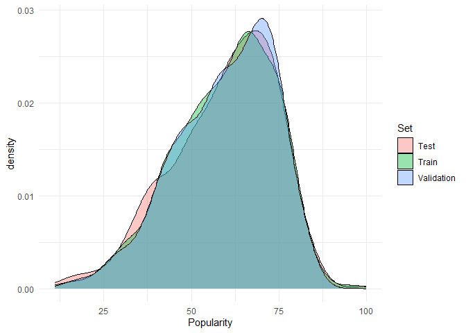

# Key Observations: (a)X-axis: Popularity (b)Y-axis: Density (c)Overall the distribution of the three sets is overlapping very closely. (d)This indicates that the model is ideally plotted and has no major distributional bias introduced during the split.

# (5) Linear Model: choosing the best model based on MSE

(a)Firstly we generated some formula in R and sourced it to our Rmrd. (b)We defined the `lm_mse` function with `lm_mse <- function(formula, train_data, valid_data)`, which means that we will train the model using the training data, but predict it using the valid data. (c)Eventually, the formula we built will give us the mean of squared errors, which is the mean of the square of the difference between the true and predicted Y values. (d)When it comes to identifying predictors we deselected some from the data so we are left only with the ones that interest us. (e)To asses the best model, we want the model with the lowest mean square errors. (f)For this step we initially classed the object `top_formulas` as a list, and the object `top_mses` as numeric. (g)In order to move on with finding the best model we are using loops, where we evaluate all the models by numbers of predictors. (h)We generated a formula, where a formula for every model is generated with regard to that model’s predictors for popularity. (i)Then, we state that MSES can be repeated from 0 until the amount of formulas we have. (j)Following that, the MSES of a specific formula can be calculated through using the `lm_mses` formula from part 4. (k)Eventually we remade the two objects, `top_formula` and `top_mses`, where the outcome of `top_formula` corresponds to the formula with the lowest MSES and the output of `top_mses` will be the actual best MSES. (l)For the final step, we want the output of our code to be written in a sentence, so we formulate a sentence, where we replace the MSES with the number corresponding to the `top_mses` rounded to 2 decimal places. (m)Other than the sentence we also add the linear formula of the model, consisting of the independent variable and its predictors.

```
[1] "Best overall formula based on MSE (MSE = 174.53 )"
```

```
[1] "Popularity ~ Year + Energy + Danceability + Loudness + Liveness + Acousticness + Speechiness"
```

# Key Observations:

# (6) Linear Model: calculating test MSE

(a)We start of by setting a function for MSE, which is the mean of the difference between the actual and predicted values squared. (b)Then we combine the train data and valid data vertically into a new variable called `train_valid` (c)Following that we make an object `best_model`, featuring the linear model of the best model function from the last part, but now trained on the training and validation sets. (d)We then use the test set to predict the best model. (e)Lastly we test the MSE, with a model trained on the train and valid data set, but predicted on the test data set. (f)We formulate our output into a phrase indicating the value of the MSE to 2 decimal places.

```
[1] "Test MSE = 192.83"
```

# Key Observations:

# (7) Showing the results graphically

(a)In order to graph our results we started off, by making a data frame of the actual and predicted results called `results_df` (b)We then used `ggplot2` again to visualize the data in a scatter plot, and decided on using `alpha = 0.6` for less overlapping. X-axis: Predicted values Y-axis: Actual values (c)Furthermore, we added a diagonal line, showing when predicted=actual, using the function `geom_abline`. (d)We added colour to the line, title to the graph, labels to the axis, and a theme. (e)To finish it up we made some justifications to the title in terms of position.

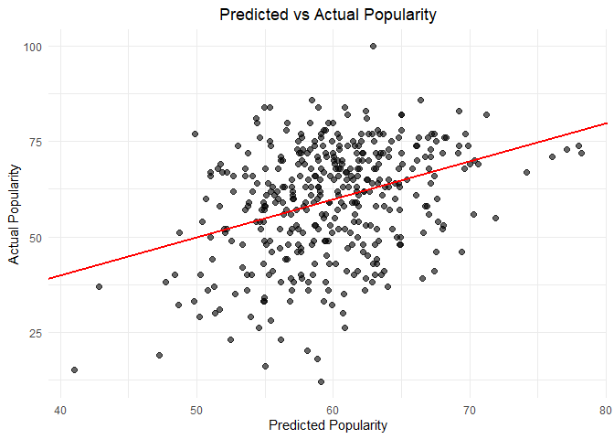

# Key Observations: (a)The points are widely spread among the values showing not very strong accuracy. (b)There is no much overlapping though, and there are a fee point on the line indicating equivalence of predicted and actual. (c)Most predicted values cluster at the values 50-65, even though actual values do at 25-80. (d)There is some bias between the two and a tendency to regress towards the mean.

# student’s contribution:

Chu Li(1082477): step 1&2(code+descriptive interpretation), creating GitHub repository Denis Lebedev (4826973): step 3 (code) + some cosmetic features for all sections Tinghui Xu (1715119):step 1&2 previous examples and revises Eleni Spyrou(4515919): step 3&4 (descriptive interpretation) # AI tools

Using ChatGPT to get inspiration for analyzing ideas